# FinalProject_itmd514_05_Anand_Abhishek

Abhishek Anand

2024-12-03

```r
# Import data file for nlsy97
nlsy <- read_csv("nlsy97.csv")
#Looking at the data
glimpse(nlsy)
```

```
## Rows: 8,984
## Columns: 95
## $ B0004600 <dbl> -4, -5, -4, -4, -5, 41, -5, -5, 251, -5, 280, -4, -5, -5, 334…
## $ E8043100 <dbl> 0, 0, 0, 0, 0, 0, 0, 0, 0, 0, 0, 0, 0, 0, 0, 0, 0, 0, 1, 0, 0…
## $ E8043200 <dbl> -4, -4, -4, -4, -4, -4, -4, -4, -4, -4, -4, -4, -4, -4, -4, -…
## $ E8043400 <dbl> -4, -4, -4, -4, -4, -4, -4, -4, -4, -4, -4, -4, -4, -4, -4, -…
## $ R0000100 <dbl> 1, 2, 3, 4, 5, 6, 7, 8, 9, 10, 11, 12, 13, 14, 15, 16, 17, 18…
## $ R0069400 <dbl> 1, 2, 2, 2, 2, 2, 2, 1, 1, 1, 2, 2, 2, 2, 2, 2, 2, 3, 4, 1, 2…
## $ R0070000 <dbl> 1, 2, 3, 3, 2, 2, 2, 1, 1, 1, 2, 2, 2, 2, 2, 3, 2, 3, 4, 2, 2…
## $ R0323900 <dbl> -4, 3, 0, -4, 3, 4, 5, -4, 1, 1, 0, -4, 1, -4, 1, 3, -4, 0, 0…
## $ R0358900 <dbl> 0, 0, 0, 0, 1, 0, 0, 0, 0, 0, 0, 0, 0, 0, 0, 0, 1, 0, 0, 0, 1…
## $ R0513500 <dbl> 10, -4, -4, 46, -4, -4, -4, 25, -4, -4, -4, 50, -4, 90, -4, -…
## $ R0514700 <dbl> 100, -4, -4, 100, -4, -4, -4, 100, -4, -4, -4, 95, -4, 100, -…
## $ R0514800 <dbl> 10, -4, -4, 0, -4, -4, -4, 0, -4, -4, -4, 0, -4, 0, -4, -4, 0…
## $ R0514900 <dbl> 0, -4, -4, 0, -4, -4, -4, -2, -4, -4, -4, 0, -4, 0, -4, -4, 2…
```

[output cut: 82 more lines]

```r
#Renaming data column(R0536300) to 'gender'
nlsy <- nlsy %>%
  rename(
    gender = `R0536300`)
```

```r
#Check the unique values and if any missing values are present
unique(nlsy$gender)
```

```
## [1] 2 1
```

```r
table(nlsy$gender, useNA = "ifany")
```

```
##
##    1    2
## 4599 4385
```

As we can see here we have a total of 4599 male and 4385 females which are denoted by 1 and 2 factor levels.

```r
# Convert gender to a factor with Male and Female labels
nlsy <- nlsy %>%
  mutate(gender = factor(gender,
                         levels = c(1, 2),
                         labels = c("Male", "Female")))
```

Renaming the factor level 1 and 2 in the gender column to Male and Female

```r
# Verify the count of Male and Female in the data
nlsy %>%
  count(gender, sort=TRUE) %>%
  rename(count = n)
```

```
## # A tibble: 2 × 2
##   gender count
##   <fct>  <int>
## 1 Male    4599
## 2 Female  4385
```

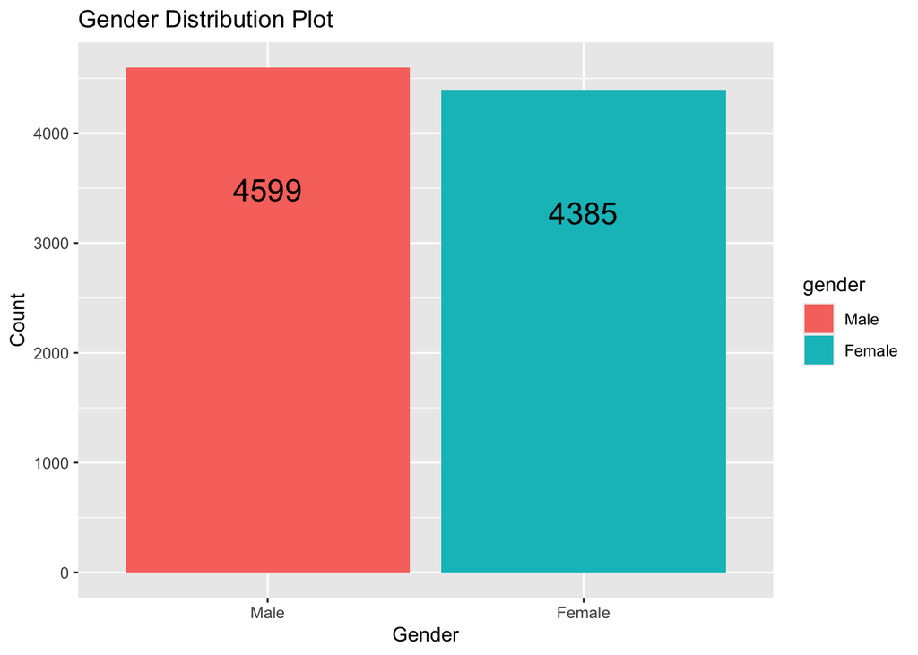

```r
# Gender Sumary
ggplot(nlsy, aes(x = gender, fill = gender)) +
  geom_bar() +
  geom_text( aes(label = ..count..), stat = "count", vjust = 6, size = 6 ) +
  labs(title = "Gender Distribution Plot", x = "Gender", y = "Count")
```

From the plot above we can see the population distribution contains more number of Male(4599) and less Females(4385).

```r
#Renaming data column(R1201400) to 'current_enrollment_status'
nlsy <- nlsy %>%
  rename(current_enrollment_status = `R1201400`)
```

```r
#Check for unique values and if any missing values are present
unique(nlsy$current_enrollment_status)
```

```
## [1]  8  1  9  3 -2 10  2
```

```r
table(nlsy$current_enrollment_status, useNA = "ifany")
```

```
##
##   -2    1    2    3    8    9   10
##    2  226    3    4 8742    5    2
```

There exist 2 values indicating Don’t Know, denoted by -2

```r
# Changing factor levels for current_enrollment_status into labels
nlsy <- nlsy %>%
  mutate(current_enrollment_status = case_when(
    current_enrollment_status == 1 ~ "Not enrolled, no high school degree, no GED",
    current_enrollment_status == 2 ~ "Not enrolled, GED",
    current_enrollment_status == 3 ~ "Not enrolled, high school degree",
    current_enrollment_status == 4 ~ "Not enrolled, some college",
    current_enrollment_status == 5 ~ "Not enrolled, 2-year college graduate",
    current_enrollment_status == 6 ~ "Not enrolled, 4-year college graduate",
    current_enrollment_status == 7 ~ "Not enrolled, graduate degree",
    current_enrollment_status == 8 ~ "Enrolled in grades 1-12, not a high school graduate",
    current_enrollment_status == 9 ~ "Enrolled in a 2-year college",
    current_enrollment_status == 10 ~ "Enrolled in a 4-year college",
    current_enrollment_status == 11 ~ "Enrolled in a graduate program",
    current_enrollment_status < 0 ~ NA_character_
  ))
```

In the above we have lebelled the enrollment statuses and also changed the negative values with NA the count of which is only 2 rows which is 2/8984 rows and ~0.02% of total data.

```r
# Verify the count of different enrollment statuses
nlsy %>%
  count(current_enrollment_status, sort = TRUE) %>%
  rename(count = n)
```

```
## # A tibble: 7 × 2
##   current_enrollment_status                           count
##   <chr>                                               <int>
## 1 Enrolled in grades 1-12, not a high school graduate  8742
## 2 Not enrolled, no high school degree, no GED           226
## 3 Enrolled in a 2-year college                            5
## 4 Not enrolled, high school degree                        4
## 5 Not enrolled, GED                                       3
## 6 Enrolled in a 4-year college                            2
## 7 <NA>                                                    2
```

From the table above we observe that 8742 of the respondants said that their current enrollment status is “Enrolled in grades 1-12, not a high school graduate” and this is followed by the ones who responsded “Not enrolled, no high school degree, no GED” which is 226.

```r
# Rename the column(U2857200) to total_income_2016
nlsy <- nlsy %>%
  rename(total_income_2016 = `U2857200`)
```

```r
#Check the data
unique(nlsy$total_income_2016)
```

```
##   [1]     -5 116000     -1  45000 125000     -2  59000  75000  36000  63000
##  [11]  35000     -4  20000  55000  40000  30000  80000  15000  85000  12000
##  [21]  50000  62000  11500  74000  27000  32000  50315 101000  17000  88000
##  [31] 140000  70000 120000  73000  86000  87000  52000  64000 103000 100000
##  [41]  90000  43000  57000  77000 235884  69000  25000  53000  51000  34000
##  [51]  65000  18000  24000 135000  28000  72000  26000  41450  93000  68000
##  [61]  83000 105000  60000  78000  76000  47000  31000   5000  48000   1000
##  [71]  10000  95000  49000  44000  22000  46000  85600 119630  54000 110000
##  [81]  37000   3000  58000  33000  92951  71000  38000   4500 115000 112000
##  [91]   6000      0   3500   9300  98000  72800  38500  23000  13000  19860
## [101]  92000    500  33600  89000  93580 121000  42798  33200  42000  55500
## [111]  41000   9700  27295   4000  39000   4625   7000  16000  34500  61000
## [121]  21000 118000 130000  96000  97000  78861   8000  20905 106000  14000
## [131]  18200    672 107000  56000   1900 112700 127000 124000  67000    350
## [141]   2885  49400  57500 143000  97885  91812    200  41300  29000 100500
```

[output cut: 22 more lines]

```r
# Handle negative values and replace with NA
nlsy <- nlsy %>%
  mutate(total_income_2016 = ifelse(total_income_2016 < 0, NA, total_income_2016))
```

```r
# Summarize the total_income_2016 column including topcoded values
summary(nlsy$total_income_2016)
```

```
##    Min. 1st Qu.  Median    Mean 3rd Qu.    Max.    NA's
##       0   25000   40000   49477   62000  235884    3893
```

```r
# Count the number of missing values including topcoded values
sum(is.na(nlsy$total_income_2016))
```

```
## [1] 3893
```

```r
# Calculate the percentage of missing values
sum(is.na(nlsy$total_income_2016)) / nrow(nlsy) * 100
```

```
## [1] 43.33259
```

```r
#Number of Topcoded values(repondents with higher income)
topcoded <- with(nlsy, sum(total_income_2016 == max(total_income_2016, na.rm = TRUE), na.rm = TRUE))
topcoded
```

```
## [1] 121
```

There are 121 topcoded values present with the income of $235,884. These 121 respondants are among the top 2% of the earners and are given an average value of $235,884

```r
# Summarize the total_income_2016 column excluding topcoded values and removing NA rows
nlsy_no_topcoded <- nlsy %>%
  filter(total_income_2016 != max(total_income_2016, na.rm = TRUE))
summary(nlsy_no_topcoded$total_income_2016)
```

```
##    Min. 1st Qu.  Median    Mean 3rd Qu.    Max.
##       0   25000   40000   44939   60000  149000
```

We have removed the respondents response who were hiding info or their responses could not be captured for their income in 2016. After removing the topcoded values it lowers the mean income from $49,477 to $44,939. The maximum income also drops from $235,884 to $149,000, which is the actual cutoff for the topcoded group. The median and IQR remain largely unchanged, showing that the central distribution of income is not significantly affected by the exclusion of topcoded values.

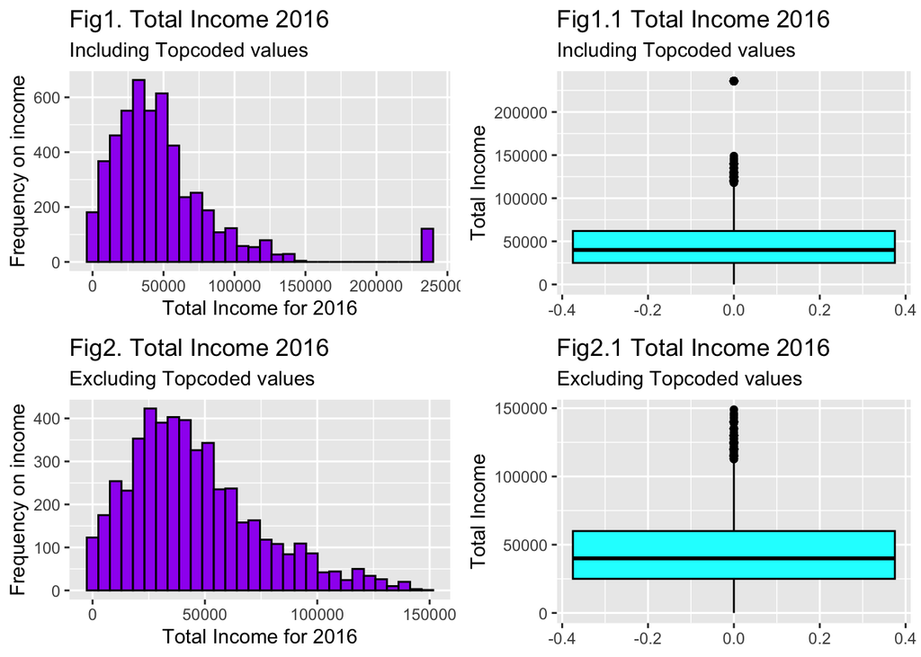

```r
# Visualizing income distribution histogram including the topcoded values
plot1 <- ggplot(nlsy, aes(x = total_income_2016)) +
  geom_histogram(bins = 30, fill = "purple", color = "black", na.rm = TRUE) +
  labs(title = "Fig1. Total Income 2016",
       subtitle = "Including Topcoded values",
       x = "Total Income for 2016",
       y = "Frequency on income")

# Visualizing income distribution boxplot  including the topcoded values
plot2 <- ggplot(nlsy, aes(y = total_income_2016)) +
  geom_boxplot(fill = "cyan", color = "black", na.rm = TRUE) +
  labs(title = "Fig1.1 Total Income 2016",
       subtitle = "Including Topcoded values",
       y = "Total Income")

# Visualizing income distribution histogram excluding the topcoded values
nlsy_no_topcoded <- nlsy %>%
  filter(total_income_2016 != max(total_income_2016, na.rm = TRUE))

plot3 <-ggplot(nlsy_no_topcoded, aes(x = total_income_2016)) +
  geom_histogram(bins = 30, fill = "purple", color = "black", na.rm = TRUE) +
  labs(title = "Fig2. Total Income 2016",
       subtitle = "Excluding Topcoded values",
       x = "Total Income for 2016",
       y = "Frequency on income")

# Visualizing income distribution boxplot excluding the topcoded values
plot4 <-ggplot(nlsy_no_topcoded, aes(y = total_income_2016)) +
  geom_boxplot(fill = "cyan", color = "black", na.rm = TRUE) +
  labs(title = "Fig2.1 Total Income 2016",
       subtitle = "Excluding Topcoded values",
       y = "Total Income")

grid.arrange(plot1, plot2, plot3, plot4, ncol = 2)
```

In the above we see that the income is topcoded and the value for the top 2% earners is replaced with average income of this group. In Fig1. the histogram is right skewed which means that there are very few high income earners but most earners make less and this skewness shows that the majority of the population earns much less than this topcoded value.

In Fig1.1 the boxplot for the same data shows that the median income is around $40,000, and the Interquartile Range (IQR) spans from $25,000 to $62,000. This means that 50% of the individuals’ incomes fall within this range. The plot also identifies the topcoded value as an outlier at $235,884, which is far outside the typical income range.

In Fig 2.when the topcoded values are removed, the histogram shows a more accurate representation of the income distribution, with the right skew still present but less extreme. This plot offers a more realistic view of the income structure, showing that the vast majority of individuals earn significantly less than $235,884.

```r
# Rename the column(R1482600) to race
nlsy <- nlsy %>%
  rename(race = `R1482600`)
```

```r
#Check for unique values and if any missing values are present
unique(nlsy$race)
```

```
## [1] 4 2 1 3
```

```r
table(nlsy$race, useNA = "ifany")
```

```
##
##    1    2    3    4
## 2335 1901   83 4665
```

Here we can see that we have the valid values from 1-4 and this column does not contain any missing values as well. Now further we can encode the numeric values to the race/ethinicity.

```r
# Recode race values into descriptive labels
nlsy <- nlsy %>%
  mutate(race = case_when(
    race == 1 ~ "Black",
    race == 2 ~ "Hispanic",
    race %in% c(3, 4) ~ "Other"  # Combine "Mixed Race" and "Non-Black" into "Other"
  )) %>%
  mutate(race = factor(race, levels = c("Black", "Hispanic", "Other")))
```

```r
# Count the number of respondents in each race group
nlsy %>%
  count(race, sort=TRUE) %>%
  rename(count = n)
```

```
## # A tibble: 3 × 2
##   race     count
##   <fct>    <int>
## 1 Other     4748
## 2 Black     2335
## 3 Hispanic  1901
```

From the count we can infer that the total population contains 4665 Non-Black, 2335 Black respondents, 1901 Hispanic and 83 Mixed Race population.

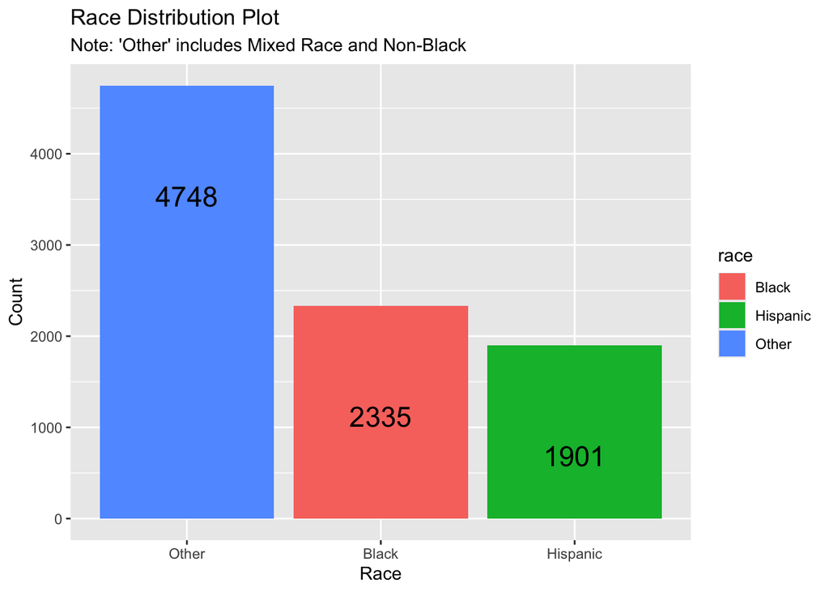

```r
# Race Summary
ggplot(nlsy, aes(x = reorder(race, -table(race)[race]), fill = race)) +
  geom_bar() +
  geom_text( aes(label = ..count..), stat = "count", vjust = 6, size = 6 ) +
  labs(title = "Race Distribution Plot", x = "Race", y = "Count",
      subtitle = "Note: 'Other' includes Mixed Race and Non-Black" )
```

```r
# Rename the column(T6767000) to highest_grade_completed
nlsy <- nlsy %>%
  rename(highest_grade_completed = `T6767000`)
```

```r
#Check for unique values and if any missing values are present
unique(nlsy$highest_grade_completed)
```

```
##  [1] -4 18 -5 15 11 14 16 12 20 19 17 13  3  5  7  6  2  8 10  1  4 -1  9  0 95
## [26] -2
```

```r
table(nlsy$highest_grade_completed, useNA = "ifany")
```

```
##
##   -5   -4   -2   -1    0    1    2    3    4    5    6    7    8    9   10   11
## 1561 5870    2    3    2    3   10    4    4    4   11    3    9   12   20   37
##   12   13   14   15   16   17   18   19   20   95
##  190  213  277  170  188  103  120   66   99    3
```

From the above we can see there are four types of negative values present which are -5, -4, -2 and -1 denoting non-interview, skipped, don’t know and refusal. Further we have to encode the values with appropiriate labels.

```r
# Replace negative values with NA
nlsy <- nlsy %>%
  mutate(highest_grade_completed = ifelse(highest_grade_completed < 0, NA, highest_grade_completed))
```

```r
# Recode highest grade completed into descriptive labels
nlsy <- nlsy %>%
  mutate(highest_grade_completed = case_when(
    highest_grade_completed == 0 ~ "None",
    highest_grade_completed == 1 ~ "1st Grade",
    highest_grade_completed == 2 ~ "2nd Grade",
    highest_grade_completed == 3 ~ "3rd Grade",
    highest_grade_completed == 4 ~ "4th Grade",
    highest_grade_completed == 5 ~ "5th Grade",
    highest_grade_completed == 6 ~ "6th Grade",
    highest_grade_completed == 7 ~ "7th Grade",
    highest_grade_completed == 8 ~ "8th Grade",
    highest_grade_completed == 9 ~ "9th Grade",
    highest_grade_completed == 10 ~ "10th Grade",
    highest_grade_completed == 11 ~ "11th Grade",
    highest_grade_completed == 12 ~ "12th Grade",
    highest_grade_completed == 13 ~ "1st Year College",
    highest_grade_completed == 14 ~ "2nd Year College",
    highest_grade_completed == 15 ~ "3rd Year College",
    highest_grade_completed == 16 ~ "4th Year College",
    highest_grade_completed == 17 ~ "5th Year College",
    highest_grade_completed == 18 ~ "6th Year College",
    highest_grade_completed == 19 ~ "7th Year College",
    highest_grade_completed == 20 ~ "8th Year College or More",
    highest_grade_completed == 95 ~ "Ungraded",
    highest_grade_completed < 0 ~ NA_character_
  ))
```

```r
# Verify the count of different grades
nlsy %>%
  count(highest_grade_completed, sort=TRUE) %>%
  rename(count = n)
```

```
## # A tibble: 23 × 2
##    highest_grade_completed  count
##    <chr>                    <int>
##  1 <NA>                      7436
##  2 2nd Year College           277
##  3 1st Year College           213
##  4 12th Grade                 190
##  5 4th Year College           188
##  6 3rd Year College           170
##  7 6th Year College           120
##  8 5th Year College           103
##  9 8th Year College or More    99
## 10 7th Year College            66
## # ℹ 13 more rows
```

From above we see that majority of the population did not answer about their grades which is 7436. From the remaining we can see that the majority of population completed 2nd year college(277) followed by 1st year college(213).

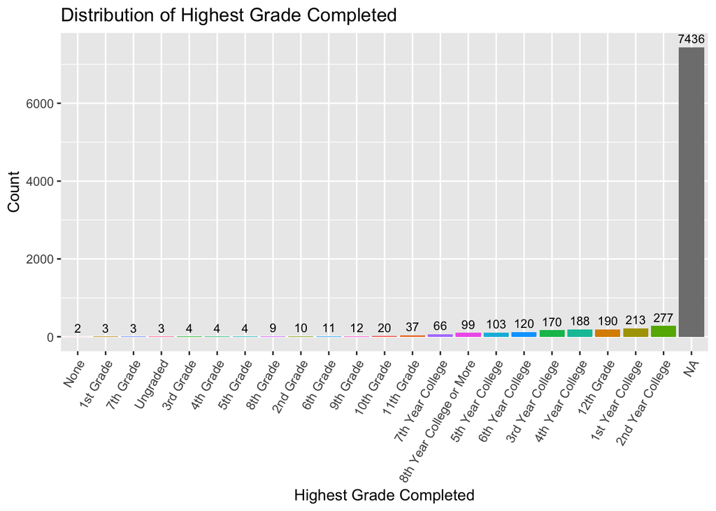

```r
# Create the plot with proper count calculation
ggplot(nlsy, aes(x = reorder(highest_grade_completed, table(highest_grade_completed)[highest_grade_completed]),  fill = highest_grade_completed)) +
  geom_bar( stat = "count",show.legend = FALSE) +
  geom_text(stat = "count", aes(label = ..count..), vjust = -0.5, size = 3) +
  labs( title = "Distribution of Highest Grade Completed", x = "Highest Grade Completed", y = "Count") +
  theme(axis.text.x = element_text(angle = 60, vjust = 1, hjust = 1))
```

From the above we see that theere are missing values for the majority of responses which is 7436. From the remaining we can see that the majority of population completed 2nd year college(277) followed by 1st year college(213).

#PART 2 Analysis

```r
# Summarize income by gender including topcoded variable, excluding NA
gender_income_summary <- nlsy %>%
  filter(!is.na(total_income_2016)) %>%  # Exclude rows with NA in income
  group_by(gender) %>%
  summarize(
    count = n(),
    mean_income = round(mean(total_income_2016, na.rm = TRUE)),
    median_income = round(median(total_income_2016, na.rm = TRUE)),
    sd_income = round(sd(total_income_2016, na.rm = TRUE))
  )
print(gender_income_summary)
```

```
## # A tibble: 2 × 5
##   gender count mean_income median_income sd_income
##   <fct>  <int>       <dbl>         <dbl>     <dbl>
## 1 Male    2621       57203         47000     44712
## 2 Female  2470       41279         35000     34047
```

```r
# Summarize income by gender excluding topcoded variable, excluding NA

#Excuding the top coded values
nlsy_no_topcoded <- nlsy %>%
  filter(!is.na(total_income_2016)) %>%
  filter(total_income_2016 != max(total_income_2016, na.rm = TRUE))

gender_income_summary <- nlsy_no_topcoded %>%
  group_by(gender) %>%
  summarize(
    count = n(),  # Count rows after filtering
    mean_income = round(mean(total_income_2016, na.rm = TRUE)),
    median_income = round(median(total_income_2016, na.rm = TRUE)),
    sd_income = round(sd(total_income_2016, na.rm = TRUE))
  )
print(gender_income_summary)
```

```
## # A tibble: 2 × 5
##   gender count mean_income median_income sd_income
##   <fct>  <int>       <dbl>         <dbl>     <dbl>
## 1 Male    2530       50776         45000     29681
## 2 Female  2440       38886         35000     26494
```

The above tabular summary for income by gender shows that males have a higher average income ($57,203) compared to females ($41,279), with a median income of $47,000 for males and $35,000 for females. The standard deviation is also higher for males ($44,712) than for females ($34,047), indicating greater income variability among males. Overall, males consistently earn more on average and have more variation in income compared to females.

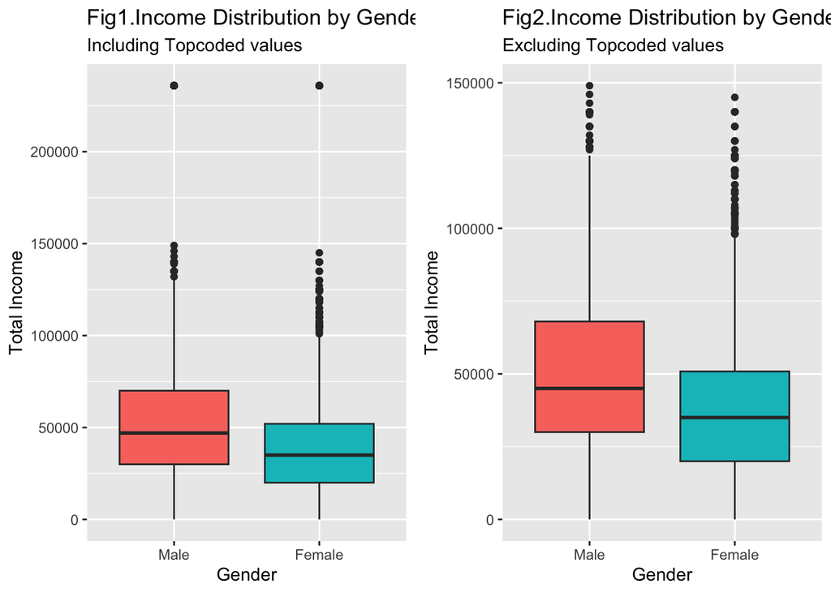

```r
plot1 <- ggplot(nlsy, aes(x = gender, y = total_income_2016, fill = gender)) +
  geom_boxplot(show.legend = FALSE, na.rm = TRUE) +
  labs(title = "Fig1.Income Distribution by Gender",
       subtitle = "Including Topcoded values",
       x = "Gender",
       y = "Total Income")

# Plot of Income with Gender excluding topcoded values
nlsy_no_topcoded <- nlsy %>%
  filter(total_income_2016 != max(total_income_2016, na.rm = TRUE))

plot2 <- ggplot(nlsy_no_topcoded, aes(x = gender, y = total_income_2016, fill = gender)) +
  geom_boxplot(show.legend = FALSE) +
  labs(title = "Fig2.Income Distribution by Gender",
       subtitle = "Excluding Topcoded values",
       x = "Gender",
       y = "Total Income")

grid.arrange(plot1, plot2, ncol = 2)
```

The box plot shows the distribution of income by gender, highlighting key differences between males and females. Males have a higher median income (indicated by the middle line of the box) compared to females. The overall spread of income is wider for males, as shown by the larger interquartile range and longer whiskers, reflecting greater income variability. From this boxplot we can say that males tend to earn more and have more income variability compared to females.

```r
# Calculate mean income by race and gender
income_by_race_gender <- nlsy %>%
  group_by(race, gender) %>%
  summarize(
    average_income = round(mean(total_income_2016, na.rm = TRUE)),
    count = n()
  )
# Display the tabular summary
income_by_race_gender
```

```
## # A tibble: 6 × 4
## # Groups:   race [3]
##   race     gender average_income count
##   <fct>    <fct>           <dbl> <int>
## 1 Black    Male            42110  1169
## 2 Black    Female          35237  1166
## 3 Hispanic Male            53326   977
## 4 Hispanic Female          36720   924
## 5 Other    Male            64519  2453
## 6 Other    Female          46240  2295
```

```r
# Calculate mean income by race and gender, excluding rows with NA in income
income_by_race_gender <- nlsy %>%
  filter(!is.na(total_income_2016)) %>%  # Exclude rows where income is NA
  group_by(race, gender) %>%
  summarize(
    average_income = round(mean(total_income_2016, na.rm = TRUE)),  # Calculate mean income
    count = n()  # Count rows after filtering
  )
# Display the tabular summary
income_by_race_gender
```

```
## # A tibble: 6 × 4
## # Groups:   race [3]
##   race     gender average_income count
##   <fct>    <fct>           <dbl> <int>
## 1 Black    Male            42110   585
## 2 Black    Female          35237   669
## 3 Hispanic Male            53326   542
## 4 Hispanic Female          36720   514
## 5 Other    Male            64519  1494
## 6 Other    Female          46240  1287
```

From the above we can see that the average income and the number of individuals for each race-gender combination, highlighting clear disparities. Males consistently earn more than females across all racial groups, with the income gap being the largest in the “Other” group ($18,279 difference) and smallest in the “Black” group ($6,873 difference). Among racial groups, individuals in the “Other” category have the highest average income for both males ($64,519) and females ($46,240), followed by “Hispanic” and “Black” groups, where males earn $53,326 and $42,110, respectively. Within each race, males and females are nearly equally represented, though males slightly outnumber females in most cases. This data reveals significant income disparities by both race and gender.

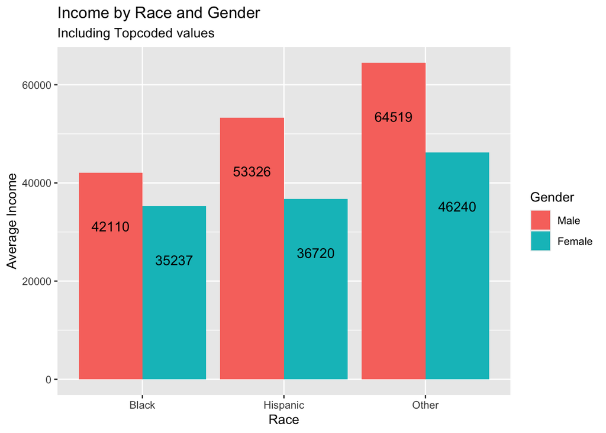

```r
# Create the bar plot for income by race and gender including topcoded values
ggplot(nlsy, aes(x = race, y = total_income_2016, fill = gender)) +
  geom_bar(stat = "summary", fun = "mean", position = "dodge", show.legend = TRUE, na.rm=TRUE) +
  geom_text(
    aes(label = round(..y..)), stat = "summary", fun = "mean", position = position_dodge(width = 0.9),vjust = 6, size = 4 ) +
  labs(
    title = "Income by Race and Gender",
    subtitle = "Including Topcoded values",
    x = "Race",
    y = "Average Income",
    fill = "Gender"
  )
```

The bar plot shows the average income by race and gender, with distinct bars for males and females within each racial group. The “Other” group has the highest average income for both males ($64,519) and females ($46,240), followed by “Hispanic” and “Black” groups. Males consistently earn more than females across all groups, with the gender gap largest in the “Other” group ($18,279) and smallest in the “Black” group ($6,873). The plot highlights significant income disparities both between races and genders.